# Ciência de Dados em R para Ciências Biológicas

Data de Publicação

29 de abril de 2026

## 🧬 O que são dados?

Dados são representações estruturadas de fenômenos observáveis. Na biologia, eles podem derivar de experimentos, observações de campo ou medições laboratoriais, como abundância de espécies, expressão gênica ou parâmetros fisiológicos.

Historicamente, a formalização de dados como objeto científico se intensificou com o desenvolvimento da estatística no século XIX, especialmente com o trabalho de cientistas como Francis Galton e Karl Pearson. Esses pesquisadores buscavam entender padrões em populações biológicas, estabelecendo as bases da análise quantitativa moderna.

Em ciência de dados, dados não são apenas números — são evidências que precisam ser interpretadas dentro de um contexto experimental e biológico.

## 🔢 Tipos de variáveis

Variáveis são características mensuráveis de um sistema. Elas podem ser classificadas em:

- **Numéricas**: representam quantidades (ex: concentração, abundância)
- **Categóricas**: representam grupos (ex: espécie, tratamento)
- **Booleanas**: representam estados binários (presença/ausência)

Essa distinção é fundamental porque cada tipo de variável exige métodos analíticos específicos. Por exemplo, correlações clássicas como Pearson só são apropriadas para variáveis numéricas contínuas.

A escolha incorreta do tipo de variável pode levar a interpretações estatísticas equivocadas.

## 🌸 Dataset iris

O dataset iris foi introduzido por Ronald Fisher em 1936 no contexto do desenvolvimento da análise discriminante linear. Ele contém medidas morfológicas de três espécies de íris.

Este dataset é historicamente importante porque foi um dos primeiros exemplos de aplicação de métodos estatísticos para classificação biológica, um problema central ainda hoje em áreas como bioinformática e ecologia.

```r
head(iris)
```

```
  Sepal.Length Sepal.Width Petal.Length Petal.Width Species
1          5.1         3.5          1.4         0.2  setosa
2          4.9         3.0          1.4         0.2  setosa
3          4.7         3.2          1.3         0.2  setosa
4          4.6         3.1          1.5         0.2  setosa
5          5.0         3.6          1.4         0.2  setosa
6          5.4         3.9          1.7         0.4  setosa
```

## 📈 Scatter plot com regressão

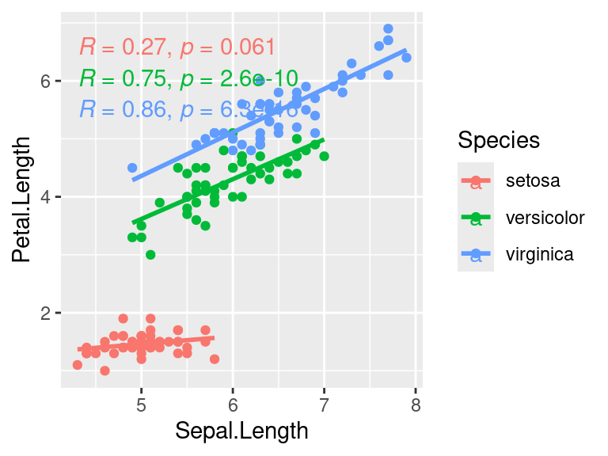

```r
library(ggplot2)
library(ggpubr)

ggplot(iris, aes(x = Sepal.Length, y = Petal.Length, color = Species)) +
  geom_point() +
  geom_smooth(method = "lm", se = FALSE) +
  stat_cor(aes(color = Species))
```

Gráficos de dispersão permitem visualizar relações entre duas variáveis contínuas. A linha de regressão linear representa a melhor aproximação dessa relação sob o critério dos mínimos quadrados, formalizado por Legendre (1805) e Gauss (1809).

O coeficiente de correlação (r) mede a força da associação linear entre variáveis, enquanto o p-valor avalia a evidência contra a hipótese nula de ausência de associação.

## 📊 Correlação de Pearson

A correlação de Pearson, desenvolvida por Karl Pearson no final do século XIX, mede a associação linear entre duas variáveis contínuas.

Ela assume: - linearidade - homocedasticidade - distribuição aproximadamente normal

```r
cor(iris$Sepal.Length, iris$Petal.Length, method = "pearson")
```

```
[1] 0.8717538
```

Matematicamente, ela representa a covariância padronizada entre duas variáveis. Valores próximos de 1 ou -1 indicam forte associação linear.

## 📊 Correlação de Spearman

A correlação de Spearman, proposta por Charles Spearman em 1904, é uma alternativa não paramétrica baseada em ranks.

```r
cor(iris$Sepal.Length, iris$Petal.Length, method = "spearman")
```

```
[1] 0.8818981
```

Ela mede relações monotônicas (não necessariamente lineares) e é mais robusta a outliers e distribuições não normais.

Isso é particularmente relevante em dados biológicos, que frequentemente violam pressupostos paramétricos.

## ⚠️ Correlação ≠ causalidade

Uma das distinções mais importantes na ciência é entre associação e causalidade.

Correlação indica que duas variáveis variam juntas, mas não explica o porquê. Como discutido por Judea Pearl, causalidade exige modelos explícitos de relação entre variáveis, frequentemente representados por grafos causais.

Exemplos clássicos incluem: - consumo de sorvete e afogamentos (variável oculta: temperatura) - biodiversidade e produtividade (potenciais fatores ambientais compartilhados)

Inferir causalidade a partir de correlação é um dos erros mais comuns em ciência.

## 🧠 Paradoxo de Simpson

O paradoxo de Simpson, descrito por Edward Simpson em 1951, ocorre quando uma tendência observada em vários grupos desaparece ou se inverte quando os dados são agregados.

Isso acontece devido à presença de variáveis de confusão que não são consideradas na análise global.

Este fenômeno é extremamente relevante em estudos biológicos, onde fatores ambientais ou experimentais podem influenciar múltiplas variáveis simultaneamente.

## 📊 Exemplo de Simpson

```r
library(dplyr)

df <- iris %>%
  mutate(group = ifelse(Species == "setosa", "A", "B"))

cor(df$Sepal.Length, df$Petal.Length)
```

```
[1] 0.8717538
```

```r
df %>%
  group_by(group) %>%
  summarise(correl = cor(Sepal.Length, Petal.Length))
```

```
# A tibble: 2 × 2
  group correl
  <chr>  <dbl>
1 A      0.267
2 B      0.828
```

Aqui vemos como a correlação global pode diferir das correlações dentro de grupos.

Isso demonstra que análises agregadas podem mascarar padrões importantes.

## 📈 Visualização do paradoxo

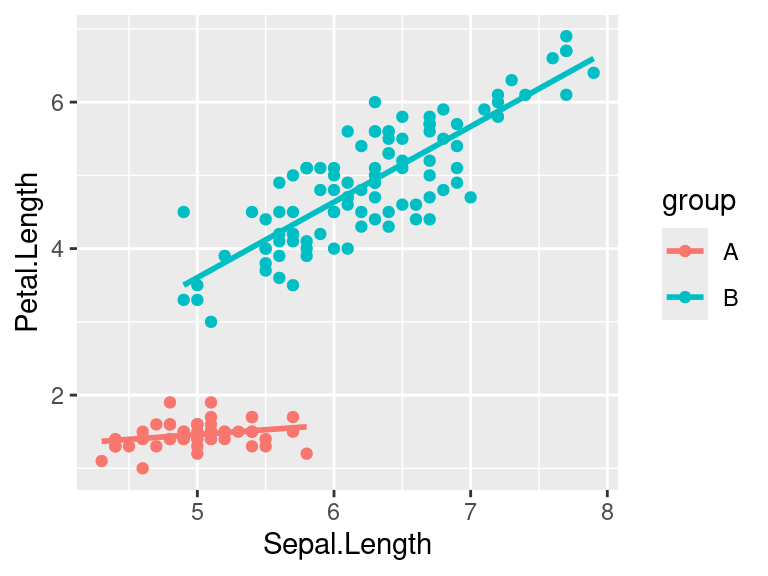

```r
ggplot(df, aes(x = Sepal.Length, y = Petal.Length, color = group)) +
  geom_point() +
  geom_smooth(method = "lm", se = FALSE)
```

A visualização permite identificar padrões que não são evidentes em métricas agregadas.

Esse princípio é central em ciência de dados: sempre explorar os dados visualmente antes de interpretar estatísticas.

## 🦖 Datasaurus

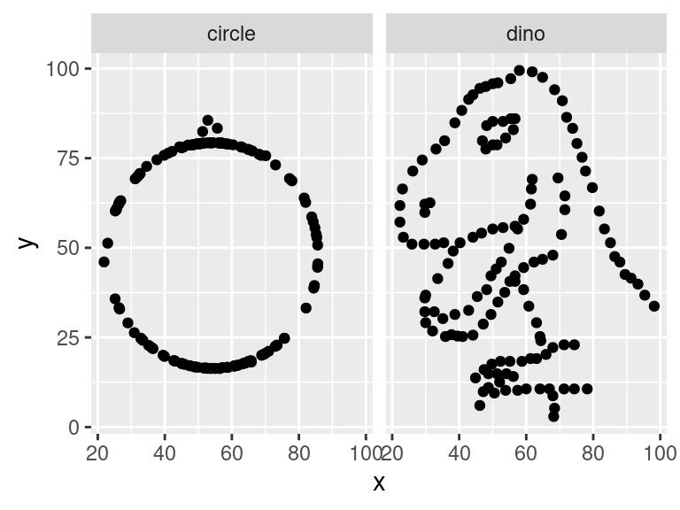

```r
library(datasauRus)

datasaurus_dozen %>%
  filter(dataset %in% c("dino","circle")) %>%
  ggplot(aes(x = x, y = y)) +
  geom_point() +
  facet_wrap(~dataset)
```

O Datasaurus Dozen demonstra que datasets com estatísticas idênticas (média, variância, correlação) podem ter distribuições completamente diferentes.

Esse exemplo reforça a importância da visualização como ferramenta crítica na análise de dados.

## 🎯 Mensagem final

A ciência de dados é tanto uma disciplina técnica quanto interpretativa.

- Métricas resumem dados, mas podem esconder padrões
- Visualizações revelam estrutura
- Correlação não implica causalidade
- Contexto biológico é essencial para interpretação

Uma análise robusta combina estatística, visualização e conhecimento do sistema estudado.